# Week 06 Homework: Random Forests

# Task: How to best classify the IKONOS imagery in Kazanlak?

Being able to classify imagery and observe change over time is helpful for development management plans for environment and cultural heritage alike. Besides the golden treasures of past kings, Kazanlak is also the world-famous producer of the rose attar. Most of it is sold to Japan for cosmetics today, however, the industry started under the Ottomans, who kept their harems happy with the rose water and oil. Wouldn’t it be nice to tell how much ground is covered with the rose fields today? Hint: roses were marked under `perennial` or `cropland` category during field survey, and teams generally avoided them, so many will be outside the survey area due to poor ground visibility. In search for the roses, practice classification of categorical rasters in R by conducting and comparing unsupervised (kmeans) and supervised (Random Forest) classification. For the Random Forests, feel free to follow [this manual](https://geoscripting-wur.github.io/AdvancedRasterAnalysis/)

- Choose a subset of the area (I recommend the East part), or downsample your raster
- Run kmeans AND random forests classification on IKONOS satellite imagery from Bulgaria
- In order to train your Random Forest classification, you should use the `kaz_training_aggr.shp` shapefiles which contain a couple polygons aggregated by landuse (annual vs perennial agriculture, beach, forest, scrub, urban, water) within the area walked in 2009-2011.
- Evaluate and compare both models. What works better and why?

## Data

The available archaeological and administrative data as well as the Aster image can be found in the Github data folder. The IKONOS satellite images (large at 2Gb a piece) can be downloaded from public [www.sciencedata.dk](https://sciencedata.dk/shared/104dc1b7a08529650379d858979ae104) folder, or directly with `file.download()` using these direct links for [West](https://sciencedata.dk/public/104dc1b7a08529650379d858979ae104/KazWestfused.tif) and [East](https://sciencedata.dk/public/104dc1b7a08529650379d858979ae104/KazEastfused.tif) respectively.

- Archaeological:
  - `KAZ_mounds` - shapefile of GPS points taken on top of each mound in Kazanlak
  - `KAZ_mdata.csv` - table of mound attributes, including Condition (1-5), Robbed (0/1), Height(numeric), and Landuse(factor)
  - `KAZ_surveyarea` - polygon shapefile of the area covered through pedestrian survey
  - `KAZ_units` - polygon shapefiles for individual survey units - arbitrary spatial containers for field observations. They range in size from 50 by 50m to 100 by 100m and their size/shape usually encompass with uniform environmental circumstances. The attributes include SU_LU and SU_AgrCond which numerically encode landuse and agricultural condition respectively, following [this coding sheet](https://docs.google.com/spreadsheets/d/14HoYRAKdi4w82nzCqhVcynGyjwrB6gutBePIs3c7Om0/edit#gid=1709790093).
  - `KAZ_training_aggr` - a few polygons aggregated by characteristic landuse

Beware that the survey dataset has the following limitations:

- teams focused on accessible areas with high visibility so annual agriculture is likely over-represented,
- categories of landuse were assigned on majority bases, so if 60% of field was ploughed and 40% was scrub, the unit is marked as annual agriculture; and
- the data is 10 years younger than the IKONOS image, captured in 2001, which can cause discrepancies. Visual checks and subsetting to areas that look best will be necessary.
- Satellite imagery
  - `KazEastfused.tif` - IKONOS image, fused panchromatic and multispectral image (resulting in 1m res) with 4 bands (BGRNIR) for **eastern** part of the valley (2Gb). Provider: Geo-Eye Foundation. Good in order to see where in the landscape the mounds are vis-a-vis towns, rivers, etc..
  - `KazWestfused.tif` - IKONOS image, fused pan+mul image (resulting in 1m res) with 4 bands (BGRNIR) for **western** part of the valley (2Gb). Provider: Geo-Eye Foundation. Good in order to see where the mounds are
  - `Aster` - digital elevation model for the Kazanlak Valley with 30m resolution. Produced by Advanced Spaceborne Thermal Emission and Reflectance Radiometer of NASA’s Terra satellite, it is now available via USGS [Application for Extracting and Exploring Analysis Ready Samples](https://lpdaacsvc.cr.usgs.gov/appeears/).

# Specify your approach and elaborate your solution here:

The first step is downloading the data (done manually) and then aggegating to get a more manageable file-size. This is NOT evaluated for everyone’s sake

```r
# Downsizing
big_raster <- raster::brick("../data/KazEastfused.tif")
smaller_raster <- raster::aggregate(big_raster, fact=10)

writeRaster(smaller_raster, "../data/KazEastSmallish.tif")
```

```r
calc_ndvi <- function(R, NIR) {
  (NIR - R) / (NIR + R)
}

pacman::p_load(raster, sf, tidyverse, ranger)
train <- st_read("../data/kaz_training_aggr.shp")
```

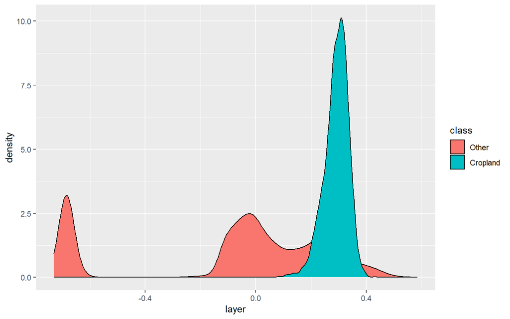

```r
kaz_raster <- brick("../data/KazEastSmallish.tif")

# Calculate NDVI
kaz_ndvi <- overlay(kaz_raster[[3]], kaz_raster[[4]], fun=calc_ndvi)

# All covariates
covs <- stack(kaz_raster, kaz_ndvi)

# Create target to be cropland or not cropland
train <- train %>%
  mutate(is_cropland = as_factor(if_else(Descr_en == "croplandhighveg", "Cropland", "Other"))) %>%
  select(is_cropland, geometry)

trainingData <- raster::extract(covs, train)


# Function to transform from raster to df
raster_to_df <- function(ras, class_name) {
  ras %>%
    as_tibble %>%
    mutate(class = class_name)
}

full_df <- map2_dfr(trainingData, train$is_cropland, raster_to_df) %>%
  as.data.frame

# Lil plot :))
full_df %>%
  ggplot(aes(x=layer, fill=class, y=..density..)) +
  geom_density()
```

```r
# This is where the fun begins!
modelRF <- ranger(x=select(full_df, -class), y=full_df$class, importance = "permutation", seed=0xfedbeef)

# Evaluating
print(modelRF$confusion.matrix)
```

```
          predicted
true       Other Cropland
  Other    53647      393
  Cropland   485     2394
```

```r
print(importance(modelRF))
```

```
KazEastSmallish.1 KazEastSmallish.2 KazEastSmallish.3 KazEastSmallish.4
       0.02408409        0.02453067        0.05312989        0.04425727
            layer
       0.04794324
```

Now it’s time for some Kmeans magic

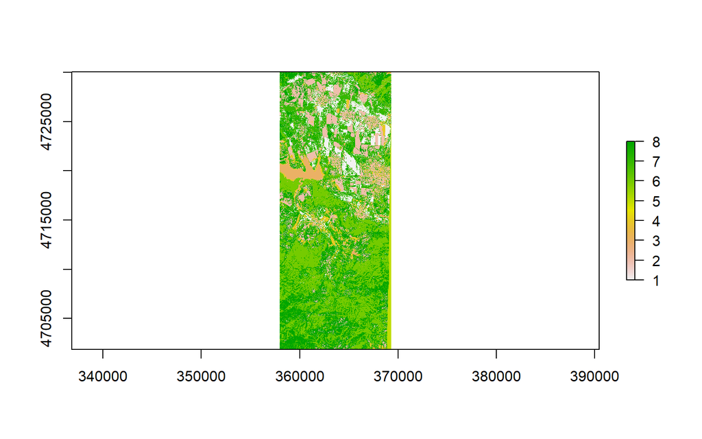

```r
# train the model
kmean_model <- kmeans(as.data.frame(stack(kaz_raster, kaz_ndvi)), 8)

# extracting the clusters
clusters <- raster(kaz_raster)
clusters <- raster::setValues(clusters, kmean_model$cluster)

# Plot and stats
plot(clusters)
```

```r
mean_zones <- zonal(stack(kaz_raster, kaz_ndvi), clusters, fun="mean")
```